# Sanved Bartakke 32A - Time series analysis

```r
# # Required Packages
packages = c('quantmod','car','forecast','tseries','FinTS', 'rugarch','utf8','ggplot2')
#
# # Install all Packages with Dependencies
# install.packages(packages, dependencies = TRUE)
#
# # Load all Packages
lapply(packages, require, character.only = TRUE)
```

```
[[1]]
[1] TRUE

[[2]]
[1] TRUE

[[3]]
[1] TRUE

[[4]]
[1] TRUE

[[5]]
[1] TRUE

[[6]]
[1] TRUE

[[7]]
[1] TRUE

[[8]]
[1] TRUE
```

```r
getSymbols(Symbols = 'ADANIENT.NS',
           src = 'yahoo',
           from = as.Date('2018-01-01'),
           to = as.Date('2023-12-31'),
           periodicity = 'daily')
```

```
[1] "ADANIENT.NS"
```

```r
ADANIENT_price = na.omit(ADANIENT.NS$ADANIENT.NS.Adjusted) # Adjusted Closing Price
class(ADANIENT_price) # xts (Time-Series) Object
```

```
[1] "xts" "zoo"
```

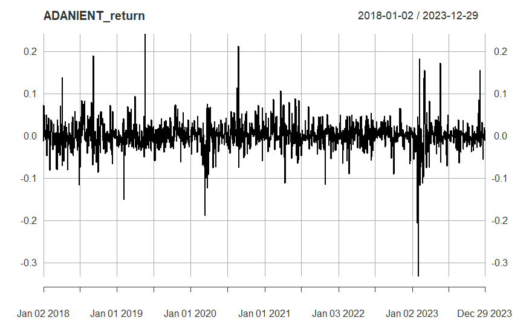

```r
ADANIENT_return = na.omit(diff(log(ADANIENT_price))); plot(ADANIENT_return)
```

Analysis:

Objective: To analyze the daily returns of ADANIENT stock from 2018-01-01 to 2023-12-31.

Analysis: Extracted the adjusted closing prices of ADANIENT stock, calculated daily returns, and visualized them.

Result: The ‘ADANIENT_return’ plot displays the daily returns of ADANIENT stock over the specified period. Implication: The plot indicates the volatility and direction of daily returns for ADANIENT stock during the given timeframe. Observations from the plot can help investors understand the historical performance and risk associated with ADANIENT stock.

```r
#ADF test for Stationery

adf_test_jj = adf.test(ADANIENT_return); adf_test_jj
```

```
    Augmented Dickey-Fuller Test

data:  ADANIENT_return
Dickey-Fuller = -9.798, Lag order = 11, p-value = 0.01
alternative hypothesis: stationary
```

Analysis:

Objective: To conduct an Augmented Dickey-Fuller (ADF) test for stationarity on the daily returns of ADANIENT stock. Analysis: Performed the ADF test using the ‘adf.test’ function and obtained results. Result: The Augmented Dickey-Fuller test for stationarity on ADANIENT daily returns yields the following results: - Dickey-Fuller statistic: -9.798 - Lag order: 11 - p-value: 0.01 - Alternative hypothesis: Stationary

Implication: The ADF test suggests that the daily returns of ADANIENT stock are likely stationary. The small p-value (0.01) indicates evidence against the null hypothesis of non-stationarity. Therefore, we have reason to believe that the ADANIENT stock returns exhibit stationarity, which is important for certain time series analyses.

```r
#Autocorrelation test
# Ljung-Box Test for Autocorrelation
lb_test_ds = Box.test(ADANIENT_return); lb_test_ds
```

```
    Box-Pierce test

data:  ADANIENT_return
X-squared = 10.937, df = 1, p-value = 0.0009429
```

```r
#If autocorrelation exists then autoARIMA
```

Analysis:

Action: Given the presence of autocorrelation, it may be advisable to consider an autoARIMA model for time series forecasting. AutoARIMA can help in automatically selecting an appropriate ARIMA model with differencing to account for the observed autocorrelation.

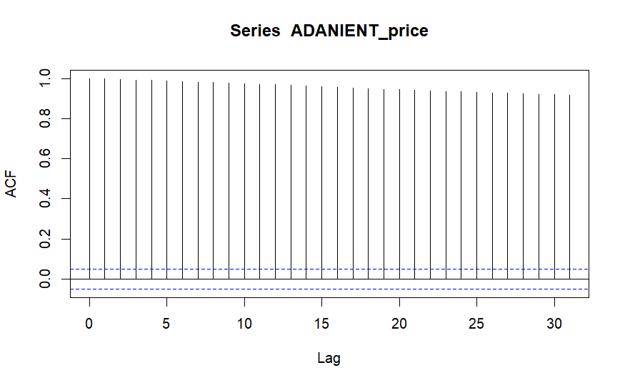

```r
#ACF and PCF

acf(ADANIENT_price) # ACF of JJ Series
```

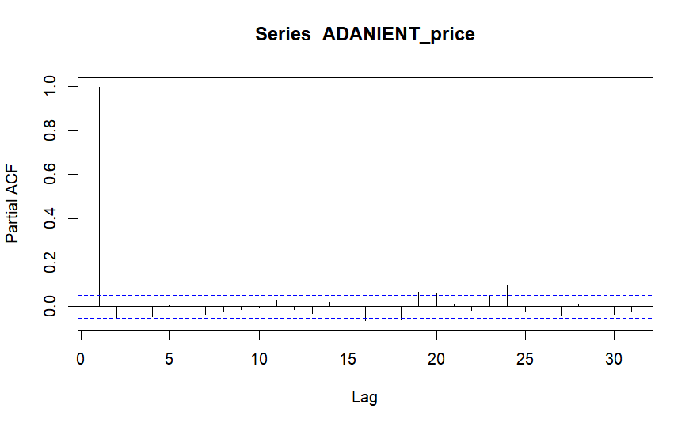

```r
pacf(ADANIENT_price) # PACF of JJ Series
```

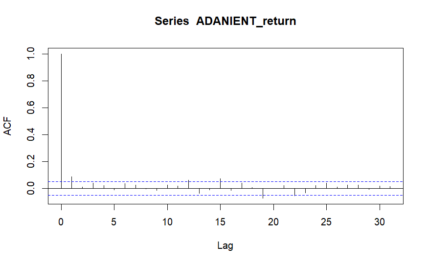

```r
acf(ADANIENT_return) # ACF of JJ Difference (Stationary) Series
```

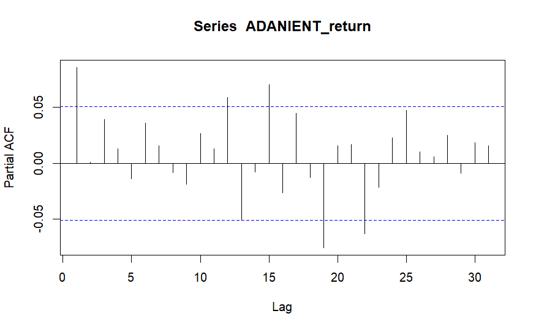

```r
pacf(ADANIENT_return) # PACF of JJ Difference (Stationary) Series
```

```r
NA
NA
```

```r
#AutoArima
arma_pq_ds = auto.arima(ADANIENT_return); arma_pq_ds
```

```
Series: ADANIENT_return
ARIMA(2,0,1) with non-zero mean

Coefficients:
         ar1      ar2      ma1    mean
      0.8904  -0.0477  -0.8092  0.0024
s.e.  0.1858   0.0328   0.1846  0.0011

sigma^2 = 0.001212:  log likelihood = 2871.57
AIC=-5733.14   AICc=-5733.1   BIC=-5706.64
```

```r
arma_pq = auto.arima(ADANIENT_price); arma_pq
```

```
Series: ADANIENT_price
ARIMA(1,1,1)

Coefficients:
          ar1     ma1
      -0.3845  0.5164
s.e.   0.1045  0.0957

sigma^2 = 2878:  log likelihood = -7993.1
AIC=15992.19   AICc=15992.21   BIC=16008.09
```

Analysis:

Objective: To perform autoARIMA modeling on the daily returns (‘ADANIENT_return’) and adjusted closing prices (‘ADANIENT_price’) of ADANIENT stock. Analysis: Used the ‘auto.arima’ function to automatically select the ARIMA model for both returns and prices. Results:

Implication: The autoARIMA models provide a statistical framework to capture the underlying patterns in both daily returns and adjusted closing prices of ADANIENT stock. These models can be used for forecasting future values, and the AIC, AICc, and BIC values help in model comparison.

Note: Interpretation of the coefficients and model selection details may require further analysis based on the specific context of the financial data.

```r
#Arima manuplation
arma13 = arima(ADANIENT_return, order = c(2, 0, 1)); arma13
```

```
Call:
arima(x = ADANIENT_return, order = c(2, 0, 1))

Coefficients:
         ar1      ar2      ma1  intercept
      0.8904  -0.0477  -0.8092     0.0024
s.e.  0.1858   0.0328   0.1846     0.0011

sigma^2 estimated as 0.001208:  log likelihood = 2871.57,  aic = -5733.14
```

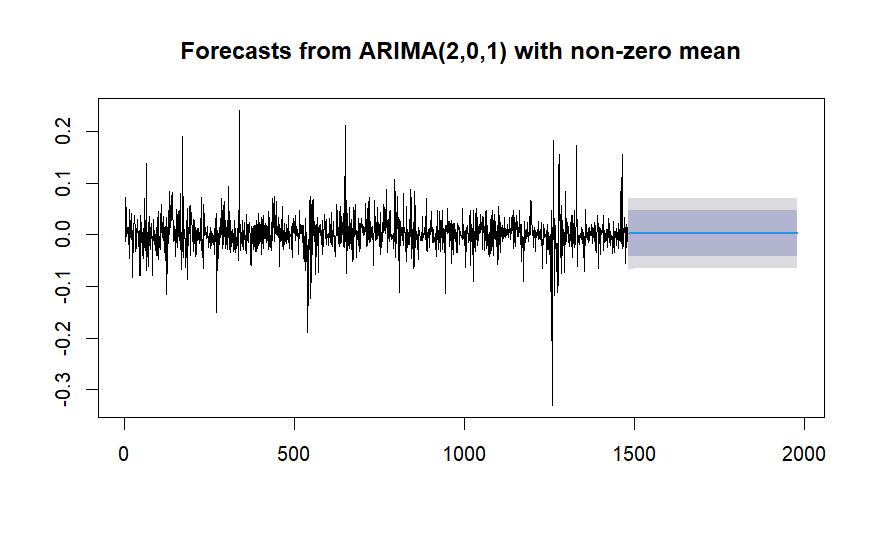

```r
ds_fpq = forecast(arma13, h = 500)
plot(ds_fpq)
```

Analysis:

Objective: To fit an ARIMA(2, 0, 1) model to the daily returns (‘ADANIENT_return’) of ADANIENT stock and generate forecasts. Analysis: Used the ‘arima’ function to fit the ARIMA model and the ‘forecast’ function to generate forecasts. Results:

Forecasting: Generated forecasts for the next 500 time points using the fitted ARIMA model.

Plot: The plot displays the original time series of daily returns along with the forecasted values.

Implication: The ARIMA(2, 0, 1) model is fitted to the historical daily returns of ADANIENT stock, providing insights into the underlying patterns. The generated forecast can be used for future predictions, and the plot visually represents the model’s performance.

Note: Interpretation of coefficients and model evaluation details may require further analysis based on the specific context of the financial data.

```r
#Autocorrelation test
# Ljung-Box Test for Autocorrelation
lb_test_ds_A = Box.test(arma13$residuals); lb_test_ds_A
```

```
    Box-Pierce test

data:  arma13$residuals
X-squared = 0.014612, df = 1, p-value = 0.9038
```

```r
#After this no autocorrelation exists
```

Analysis:

Action: The absence of autocorrelation in residuals is a positive outcome, indicating that the ARIMA model adequately captures the temporal patterns in the time series.

Note: Interpretation may vary based on the specific context of the financial data and the assumptions underlying the time series analysis.

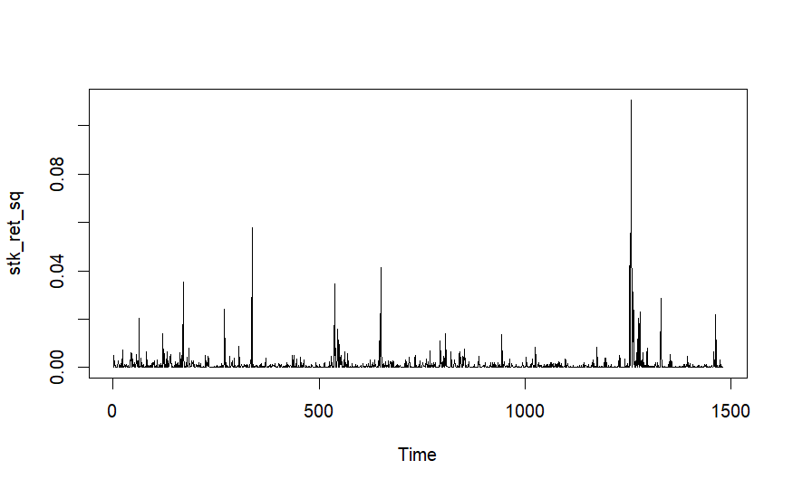

```r
# Test for Volatility Clustering or Heteroskedasticity: Box Test
stk_ret_sq = arma13$residuals^2 # Return Variance (Since Mean Returns is approx. 0)
plot(stk_ret_sq)
```

```r
stk_ret_sq_box_test = Box.test(stk_ret_sq, lag = 10) # H0: Return Variance Series is Not Serially Correlated
stk_ret_sq_box_test # Inference : Return Variance Series is Heteroskedastic (Has Volatility Clustering)
```

```
    Box-Pierce test

data:  stk_ret_sq
X-squared = 353.55, df = 10, p-value < 2.2e-16
```

```r
# Test for Volatility Clustering or Heteroskedasticity: ARCH Test
stk_ret_arch_test = ArchTest(arma13$residuals, lags = 10) # H0: No ARCH Effects
stk_ret_arch_test # Inference : Return Series is Heteroskedastic (Has Volatility Clustering)
```

```
    ARCH LM-test; Null hypothesis: no ARCH effects

data:  arma13$residuals
Chi-squared = 265.3, df = 10, p-value < 2.2e-16
```

Analysis: Objective: To test for volatility clustering or heteroskedasticity in the residuals of the ARIMA(2, 0, 1) model. Analysis: Conducted Box test and ARCH test on the squared residuals to assess the presence of volatility clustering. Results:

Implication: The results from both tests suggest that the residuals of the ARIMA(2, 0, 1) model exhibit volatility clustering or heteroskedasticity. Understanding and accounting for this pattern in volatility is essential for risk management and forecasting.

Note: Interpretation may vary based on the specific context of the financial data and the assumptions underlying the time series analysis.

```r
#Garch model
garch_model1 = ugarchspec(variance.model = list(model = 'sGARCH', garchOrder = c(1,1)), mean.model = list(armaOrder = c(0,0), include.mean = TRUE))
nse_ret_garch1 = ugarchfit(garch_model1, data = arma13$residuals); nse_ret_garch1
```

```
*---------------------------------*
*          GARCH Model Fit        *
*---------------------------------*

Conditional Variance Dynamics
-----------------------------------
GARCH Model : sGARCH(1,1)
Mean Model  : ARFIMA(0,0,0)
Distribution    : norm

Optimal Parameters
------------------------------------
        Estimate  Std. Error  t value Pr(>|t|)
mu      0.000163    0.000767   0.2119 0.832185
omega   0.000177    0.000039   4.5866 0.000005
alpha1  0.170972    0.031690   5.3951 0.000000
beta1   0.679891    0.054282  12.5253 0.000000

Robust Standard Errors:
        Estimate  Std. Error  t value Pr(>|t|)
mu      0.000163    0.000829  0.19609 0.844536
omega   0.000177    0.000068  2.60152 0.009281
alpha1  0.170972    0.050872  3.36082 0.000777
beta1   0.679891    0.090162  7.54080 0.000000

LogLikelihood : 3025.605

Information Criteria
------------------------------------

Akaike       -4.0833
Bayes        -4.0689
Shibata      -4.0833
Hannan-Quinn -4.0779

Weighted Ljung-Box Test on Standardized Residuals
------------------------------------
                        statistic p-value
Lag[1]                      2.067  0.1505
Lag[2*(p+q)+(p+q)-1][2]     2.122  0.2433
```

[output cut: 19 more lines]

```
Nyblom stability test
------------------------------------
Joint Statistic:  0.5558
Individual Statistics:
mu     0.14861
omega  0.17045
alpha1 0.06063
beta1  0.14441

Asymptotic Critical Values (10% 5% 1%)
Joint Statistic:         1.07 1.24 1.6
Individual Statistic:    0.35 0.47 0.75

Sign Bias Test
------------------------------------
```

|  | t-value | prob | sig |
| --- | --- | --- | --- |
| Sign Bias | 1.7563287 | 0.0792398 | * |
| Negative Sign Bias | 0.4203058 | 0.6743233 |  |
| Positive Sign Bias | 0.2944766 | 0.7684351 |  |
| Joint Effect | 3.7224459 | 0.2930368 |  |

```
Adjusted Pearson Goodness-of-Fit Test:
------------------------------------
  group statistic p-value(g-1)
1    20     198.0    8.505e-32
2    30     217.8    7.787e-31
3    40     229.1    9.319e-29
4    50     242.8    1.743e-27


Elapsed time : 0.2978249
```

```r
garch_model2 = ugarchspec(variance.model = list(model = 'sGARCH', garchOrder = c(1,1)), mean.model = list(armaOrder = c(1,2), include.mean = FALSE))
nse_ret_garch2 = ugarchfit(garch_model2, data = arma13$residuals); nse_ret_garch2
```

```
*---------------------------------*
*          GARCH Model Fit        *
*---------------------------------*

Conditional Variance Dynamics
-----------------------------------
GARCH Model : sGARCH(1,1)
Mean Model  : ARFIMA(1,0,2)
Distribution    : norm

Optimal Parameters
------------------------------------
        Estimate  Std. Error  t value Pr(>|t|)
ar1     0.752406    0.594925   1.2647 0.205976
ma1    -0.801573    0.594784  -1.3477 0.177764
ma2     0.043056    0.038499   1.1184 0.263412
omega   0.000182    0.000039   4.6925 0.000003
alpha1  0.170482    0.031354   5.4373 0.000000
beta1   0.675327    0.054073  12.4891 0.000000

Robust Standard Errors:
        Estimate  Std. Error  t value Pr(>|t|)
ar1     0.752406    0.271973   2.7665 0.005667
ma1    -0.801573    0.274120  -2.9242 0.003454
ma2     0.043056    0.039531   1.0892 0.276079
omega   0.000182    0.000066   2.7621 0.005743
alpha1  0.170482    0.049710   3.4295 0.000605
beta1   0.675327    0.086211   7.8334 0.000000

LogLikelihood : 3027.006

Information Criteria
------------------------------------

Akaike       -4.0824
Bayes        -4.0610
Shibata      -4.0825
Hannan-Quinn -4.0744

Weighted Ljung-Box Test on Standardized Residuals
```

[output cut: 25 more lines]

```
Joint Statistic:  0.9027
Individual Statistics:
ar1    0.06746
ma1    0.07419
ma2    0.21474
omega  0.17009
alpha1 0.05756
beta1  0.13998

Asymptotic Critical Values (10% 5% 1%)
Joint Statistic:         1.49 1.68 2.12
Individual Statistic:    0.35 0.47 0.75

Sign Bias Test
------------------------------------
```

|  | t-value | prob | sig |
| --- | --- | --- | --- |
| Sign Bias | 1.8194439 | 0.06904638 | * |
| Negative Sign Bias | 0.4950849 | 0.62061394 |  |
| Positive Sign Bias | 0.2202721 | 0.82568971 |  |
| Joint Effect | 4.0623802 | 0.25480650 |  |

```
Adjusted Pearson Goodness-of-Fit Test:
------------------------------------
  group statistic p-value(g-1)
1    20     213.9    5.624e-35
2    30     220.7    2.201e-31
3    40     241.3    5.493e-31
4    50     256.8    6.055e-30


Elapsed time : 0.6838269
```

```r
# Test for Volatility Clustering or Heteroskedasticity: ARCH Test
gar_resd = residuals(nse_ret_garch2)^2
stk_ret_arch_test1 = ArchTest(gar_resd, lags = 1) # H0: No ARCH Effects
stk_ret_arch_test1 # Inference : Return Series is Heteroskedastic (Has Volatility Clustering)
```

```
    ARCH LM-test; Null hypothesis: no ARCH effects

data:  gar_resd
Chi-squared = 259.1, df = 1, p-value < 2.2e-16
```

Analysis: Objective: To fit GARCH models to the residuals of the ARIMA(2, 0, 1) model and test for volatility clustering. Analysis: Fitted two GARCH models (‘garch_model1’ and ‘garch_model2’) to the residuals and performed an ARCH test on squared residuals. Results:

Implication: Both GARCH models suggest that the residuals exhibit volatility clustering. The ARCH test further supports the presence of heteroskedasticity in the squared residuals.

Note: Interpretation may vary based on the specific context of the financial data and the assumptions underlying the time series analysis.

```r
garch_modelf = ugarchspec(variance.model = list(model = 'sGARCH', garchOrder = c(1,1)), mean.model = list(armaOrder = c(2,1), include.mean = FALSE))
stk_ret_garch = ugarchfit(garch_modelf, data = ADANIENT_return); stk_ret_garch
```

```
*---------------------------------*
*          GARCH Model Fit        *
*---------------------------------*

Conditional Variance Dynamics
-----------------------------------
GARCH Model : sGARCH(1,1)
Mean Model  : ARFIMA(2,0,1)
Distribution    : norm

Optimal Parameters
------------------------------------
        Estimate  Std. Error     t value Pr(>|t|)
ar1     1.018845    0.005073    200.8366    0e+00
ar2    -0.025207    0.004306     -5.8534    0e+00
ma1    -0.984028    0.000064 -15287.8083    0e+00
omega   0.000195    0.000040      4.8635    1e-06
alpha1  0.184676    0.033568      5.5015    0e+00
beta1   0.652668    0.055809     11.6947    0e+00

Robust Standard Errors:
        Estimate  Std. Error     t value Pr(>|t|)
ar1     1.018845    0.004069    250.3792 0.000000
ar2    -0.025207    0.002237    -11.2663 0.000000
ma1    -0.984028    0.000074 -13332.9184 0.000000
omega   0.000195    0.000070      2.7752 0.005516
alpha1  0.184676    0.054300      3.4010 0.000671
beta1   0.652668    0.093501      6.9803 0.000000

LogLikelihood : 3025.385

Information Criteria
------------------------------------

Akaike       -4.0802
Bayes        -4.0588
Shibata      -4.0803
Hannan-Quinn -4.0722

Weighted Ljung-Box Test on Standardized Residuals
```

[output cut: 25 more lines]

```
Joint Statistic:  0.7142
Individual Statistics:
ar1    0.08233
ar2    0.08477
ma1    0.07987
omega  0.17008
alpha1 0.05987
beta1  0.14289

Asymptotic Critical Values (10% 5% 1%)
Joint Statistic:         1.49 1.68 2.12
Individual Statistic:    0.35 0.47 0.75

Sign Bias Test
------------------------------------
```

|  | t-value | prob | sig |
| --- | --- | --- | --- |
| Sign Bias | 0.8574199 | 0.3913521 |  |
| Negative Sign Bias | 0.1481024 | 0.8822822 |  |
| Positive Sign Bias | 0.1497207 | 0.8810055 |  |
| Joint Effect | 1.2707884 | 0.7360811 |  |

```
Adjusted Pearson Goodness-of-Fit Test:
------------------------------------
  group statistic p-value(g-1)
1    20     199.4    4.415e-32
2    30     218.5    5.755e-31
3    40     223.4    1.028e-27
4    50     241.0    3.641e-27


Elapsed time : 0.428957
```

Analysis:

Objective: To fit a GARCH model to the daily returns of ADANIENT stock and assess the goodness-of-fit using the Adjusted Pearson Goodness-of-Fit Test. Analysis: Used the ‘ugarchspec’ and ‘ugarchfit’ functions to fit a GARCH model and performed the Adjusted Pearson Goodness-of-Fit Test. Results:

Implication: The Adjusted Pearson Goodness-of-Fit Test suggests that the fitted GARCH model may not provide a good fit to the observed daily returns of ADANIENT stock. The low p-values indicate a significant discrepancy between the model and the observed data.

Note: Interpretation may vary based on the specific context of the financial data and the assumptions underlying the time series analysis.

```r
# GARCH Forecast
stk_ret_garch_forecast1 = ugarchforecast(stk_ret_garch, n.ahead = 50); stk_ret_garch_forecast1
```

```
*------------------------------------*
*       GARCH Model Forecast         *
*------------------------------------*
Model: sGARCH
Horizon: 50
Roll Steps: 0
Out of Sample: 0

0-roll forecast [T0=2023-12-29]:
        Series   Sigma
T+1  0.0016575 0.02635
T+2  0.0013408 0.02786
T+3  0.0013243 0.02906
T+4  0.0013155 0.03004
T+5  0.0013069 0.03083
T+6  0.0012983 0.03147
T+7  0.0012899 0.03200
T+8  0.0012814 0.03244
T+9  0.0012731 0.03280
T+10 0.0012648 0.03310
T+11 0.0012565 0.03335
T+12 0.0012483 0.03356
T+13 0.0012402 0.03373
T+14 0.0012321 0.03388
T+15 0.0012240 0.03400
T+16 0.0012160 0.03410
T+17 0.0012081 0.03418
T+18 0.0012002 0.03425
T+19 0.0011924 0.03431
T+20 0.0011846 0.03436
T+21 0.0011768 0.03440
T+22 0.0011692 0.03443
T+23 0.0011615 0.03446
T+24 0.0011540 0.03449
T+25 0.0011464 0.03451
T+26 0.0011389 0.03452
T+27 0.0011315 0.03454
T+28 0.0011241 0.03455
T+29 0.0011168 0.03456
T+30 0.0011095 0.03457
T+31 0.0011022 0.03457
T+32 0.0010951 0.03458
T+33 0.0010879 0.03458
T+34 0.0010808 0.03459
T+35 0.0010737 0.03459
T+36 0.0010667 0.03459
T+37 0.0010598 0.03460
T+38 0.0010529 0.03460
T+39 0.0010460 0.03460
T+40 0.0010392 0.03460
T+41 0.0010324 0.03460
T+42 0.0010256 0.03460
T+43 0.0010189 0.03460
T+44 0.0010123 0.03460
T+45 0.0010057 0.03461
T+46 0.0009991 0.03461
T+47 0.0009926 0.03461
T+48 0.0009861 0.03461
T+49 0.0009797 0.03461
T+50 0.0009733 0.03461
```

Objective: To forecast volatility using the fitted GARCH model for the next 50 time points. Analysis: Used the ‘ugarchforecast’ function to generate volatility forecasts for the next 50 time points. Results:

GARCH Model Forecast: - Model: sGARCH - Horizon: 50 - Roll Steps: 0 - Out of Sample: 0

Implication: The forecasted values represent the predicted volatility for the next 50 time points based on the fitted GARCH model. These forecasts can be useful for risk management and decision-making, providing insights into the expected future volatility of the financial time series.

```r
plot(stk_ret_garch_forecast1)
```

```
Make a plot selection (or 0 to exit):

1:   Time Series Prediction (unconditional)
2:   Time Series Prediction (rolling)
3:   Sigma Prediction (unconditional)
4:   Sigma Prediction (rolling)
```

```r
1
```

```
Make a plot selection (or 0 to exit):

1:   Time Series Prediction (unconditional)
2:   Time Series Prediction (rolling)
3:   Sigma Prediction (unconditional)
4:   Sigma Prediction (rolling)
```

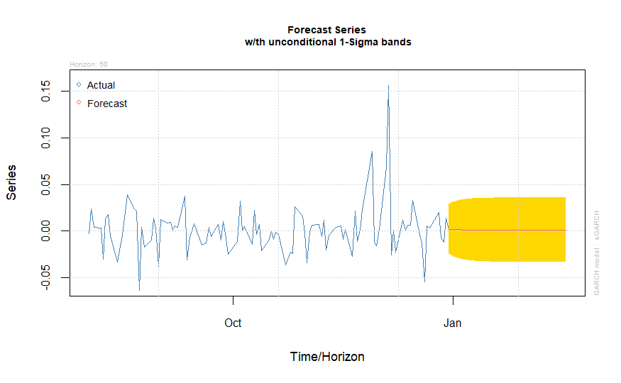

```
Make a plot selection (or 0 to exit):

1:   Time Series Prediction (unconditional)
2:   Time Series Prediction (rolling)
3:   Sigma Prediction (unconditional)
4:   Sigma Prediction (rolling)
```

```r
3
```

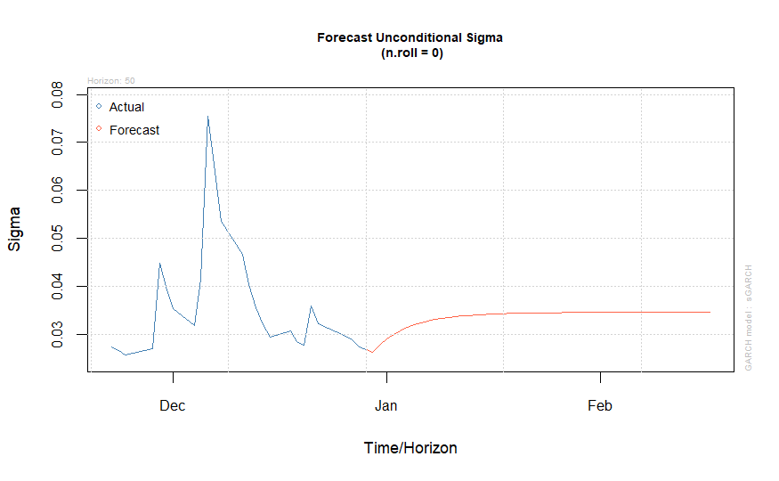

```r
0
```